# Forecasting football injuries by combining screening, monitoring and machine learning - 2/4 Ancillary Data analysis: Leaky folds

Anne Hecksteden & Georges Pierre Schmartz

17 May 2022

```r
# clean workspace if needed
rm(list = ls())
source("utils.R")
data<-get_main_data()
data_test<-data$data_test
data_training<-data$data_training

# Work with multiple threads (use all of the available ones)
cl <- makePSOCKcluster(14)
registerDoParallel(cl)
```

# Ancillary analysis 2: Information Leakage

In Monitoring datasets, timepoints are nested within players. This hierarchical structure has to be considered when setting up cross-validation, specifically cross-validation folds must be constructed on the level of players - not datapoints. Otherwise leaking of information between folds can lead to a spurious increase in cross-validation performance metrics (which does not generalize to test set performance or future data).

Another potential cause of information leakage and inflated cross-validation performance is the timepoint of upsampling. When upsampling the training set before cross-validation, resamples or descendants of the same case will be included in several folds (and therefore used for training and testing the same model). Therefore, in the main analysis of this work, upsampling is integrated into cross-validation.

Of note, the magnitude of the respective effects of these two potential sources of information leakage are dependent on the characteristics of the use-case including the structure of the dataset and the details of the analytical procedures.

The above aspects are not generally considered in previous work, complicating the comparison of cross-validation results. This ancillary analysis aims to demonstrate these considerations and probe their relevance for the specific case of our dataset.Three variations of the main analysis are presented

2a) Upsampling integrated into cross validation (as in main analysis) but no consideration of hierarchical data structure

2b) Upsampling outside cross-validation

2c) Upsampling outside cross-validation and no consideration of hierarchical data structure (combines both potential leaks)

In short, the results indicate that when only one of the two potential information-leaks is “open” (variant 2a and 2b) model performance is not to far off the results of the main analysis. However, marked overfitting is observed when the two leaks are combined (variant 2c)

# 2a) Main model - but no consideration of hierarchical data structure

## Fit gradient-boosted model

```r
trainctrl_leaky <- trainControl(method = "repeatedcv", number = data$player_in_training, repeats = 10, summaryFunction = twoClassSummary, classProbs = TRUE, savePredictions = TRUE, sampling = rose_upsampling)  # no index argument (CV_folds not used)!

set.seed(42)
gbm_tree_auto_leaky1 <- train(Crit ~ ., data = data_training, method = "gbm", metric = "ROC", trControl = trainctrl_leaky, verbose = FALSE, tuneGrid = gbmGrid)
# Show model
gbm_tree_auto_leaky1
```

```
## Stochastic Gradient Boosting
##
## 12664 samples
##    13 predictor
##     2 classes: 'No', 'Yes'
##
## No pre-processing
## Resampling: Cross-Validated (65 fold, repeated 10 times)
## Summary of sample sizes: 12470, 12469, 12469, 12468, 12469, 12469, ...
## Addtional sampling using
##
## Resampling results across tuning parameters:
##
##   interaction.depth  n.trees  ROC        Sens       Spec
##    1                  25      0.6148639  0.9236357  0.2200
```

[output cut: 81 more lines]

```r
#End Parallel Computation
stopCluster(cl)
registerDoSEQ()
```

## Get cross-validation performance metrics

### ROC curve

```r
# Work with multiple threads (use all of the available ones)
gc()
```

```
##            used  (Mb) gc trigger   (Mb)  max used   (Mb)
## Ncells  2549286 136.2    4152725  221.8   4152725  221.8
## Vcells 91032597 694.6  216983523 1655.5 208659123 1592.0
```

```r
cl <- makePSOCKcluster(14)
registerDoParallel(cl)

# Extract from fit object
predicted <- as.data.frame(gbm_tree_auto_leaky1$pred$pred)
observed <- as.data.frame(gbm_tree_auto_leaky1$pred$obs)
prob_no <- as.data.frame(gbm_tree_auto_leaky1$pred$No)
prob_yes <- as.data.frame(gbm_tree_auto_leaky1$pred$Yes)

# ROC curve and AUC
cv_roc_leaky1 <- cbind(predicted, observed, prob_no, prob_yes)
names(cv_roc_leaky1) <- c("pred", "obs", "prob_no", "prob_yes")


cv_roc_leaky1$obs_i <- cv_roc_leaky1$obs == "Yes"

temporary<-generate_rocs(cv_roc_leaky1)
```

```
## Progress disabled when using parallel plyr
```

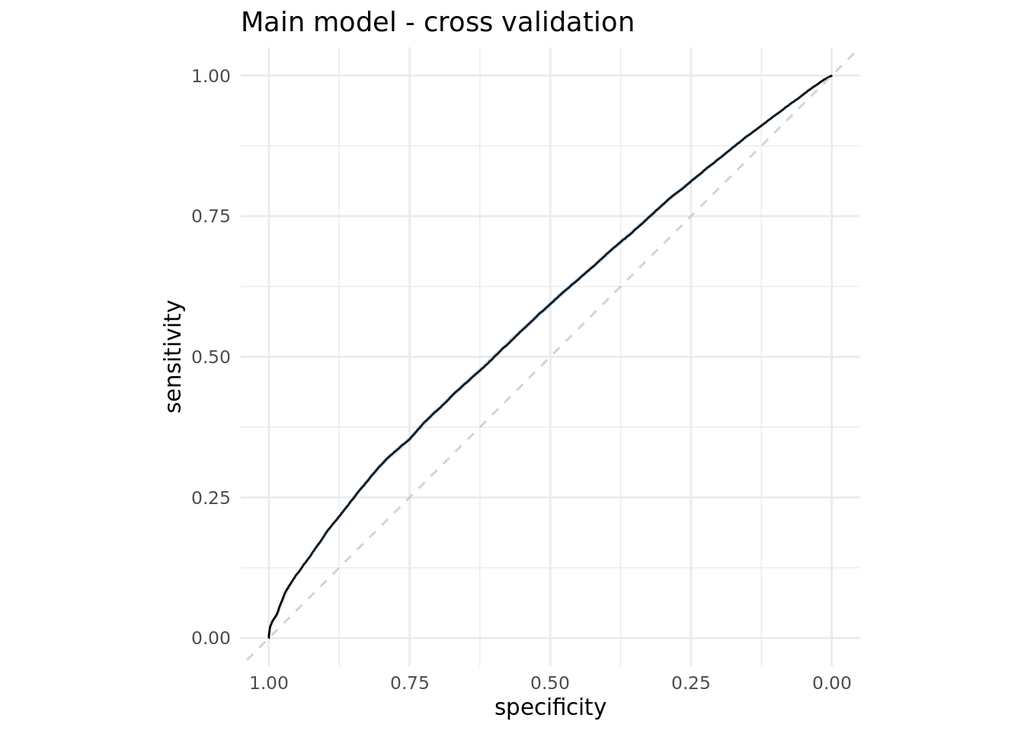

```r
# ROC curve with confidence interval
temporary$roc_plot
```

```r
# ROC-AUC
temporary$auc
```

```
## Area under the curve: 0.5746
```

```r
# ROC-AUC confidence interval
temporary$auc_ci
```

```
## 95% CI: 0.5712-0.5779 (DeLong)
```

### Discrimination - violin plots

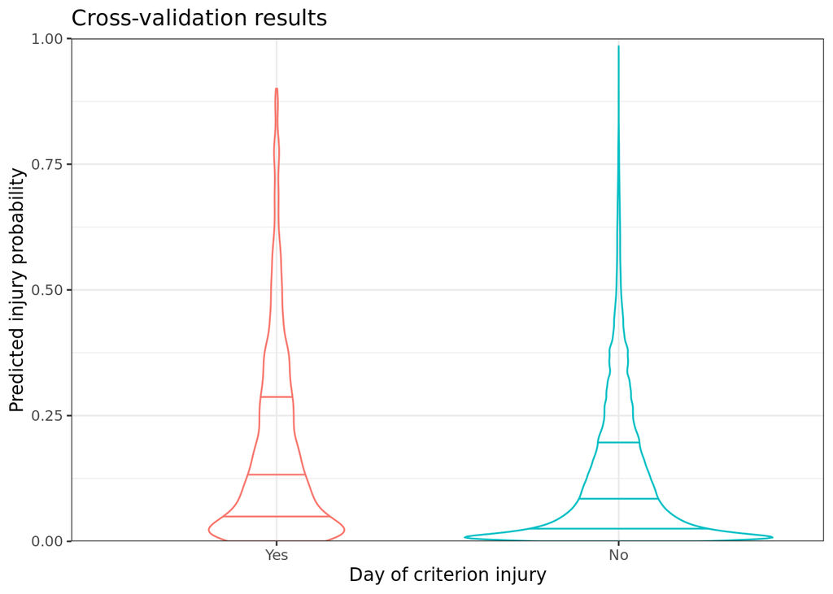

```r
violin_plot(cv_roc_leaky1)
```

## Get testset predictions

```r
# Apply to test set
Predicted_leaky1 <- predict(gbm_tree_auto_leaky1, newdata=data_test)

# View predictions for the test set
Predicted_leaky1 <- data.frame(Predicted_leaky1)

# Merge with testset
data_test_plus_leaky1 <- cbind(data_test, Predicted_leaky1)
data_test_plus_leaky1$Predicted_leaky1 <- factor(data_test_plus_leaky1$Predicted_leaky1, levels = c("No", "Yes"))

# Check confusion matrix
table(data_test_plus_leaky1$Crit, data_test_plus_leaky1$Predicted_leaky1)
```

```
##
##         No  Yes
##   No  4299  244
##   Yes   10    1
```

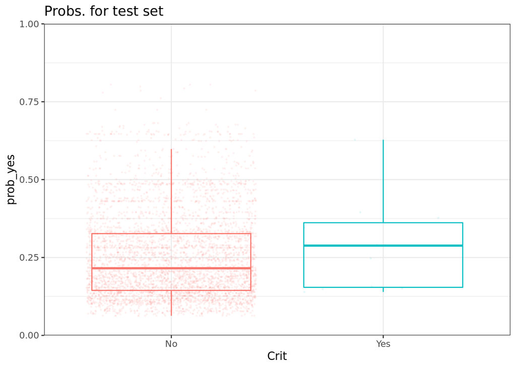

```r
## Get probabilities
Predicted_leaky1p <- predict(gbm_tree_auto_leaky1, newdata=data_test, type = "prob")
colnames(Predicted_leaky1p) <- c("prob_no", "prob_yes")

# Merge
data_test_plus_leaky1 <- cbind(data_test_plus_leaky1, Predicted_leaky1p)

# Plot
ggplot(data_test_plus_leaky1, aes(x=Crit, y=prob_yes, color = Crit))+ geom_jitter(alpha=0.1,size=0.6,shape=16)+ geom_boxplot(outlier.shape = NA,fill=NA)   + ggtitle("Probs. for test set")+guides(color="none")+ggplot_theme+scale_y_continuous(expand=c(0,0),limits = c(0,1))
```

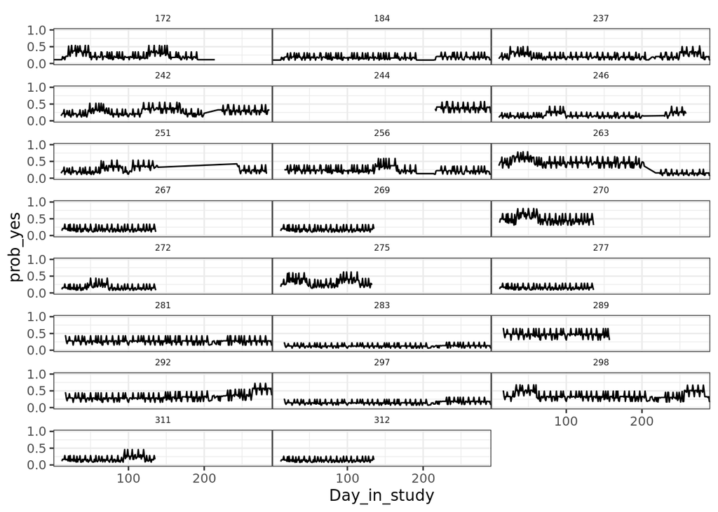

```r
ggplot(data_test_plus_leaky1, aes(x=Day_in_study, y=prob_yes) ) + geom_line() +facet_wrap(~ID,ncol = 3) +scale_y_continuous(limits = c(0,1),breaks = c(0,0.5,1))+ggplot_theme+theme(strip.background = element_blank(),strip.text = element_text(size=6),panel.spacing = unit(0, "lines"))+scale_x_continuous(expand=c(0,0))
```

## Testset performance

### ROC curve

```r
temporary<-generate_rocs(data_test_plus_leaky1)
```

```
## Progress disabled when using parallel plyr
```

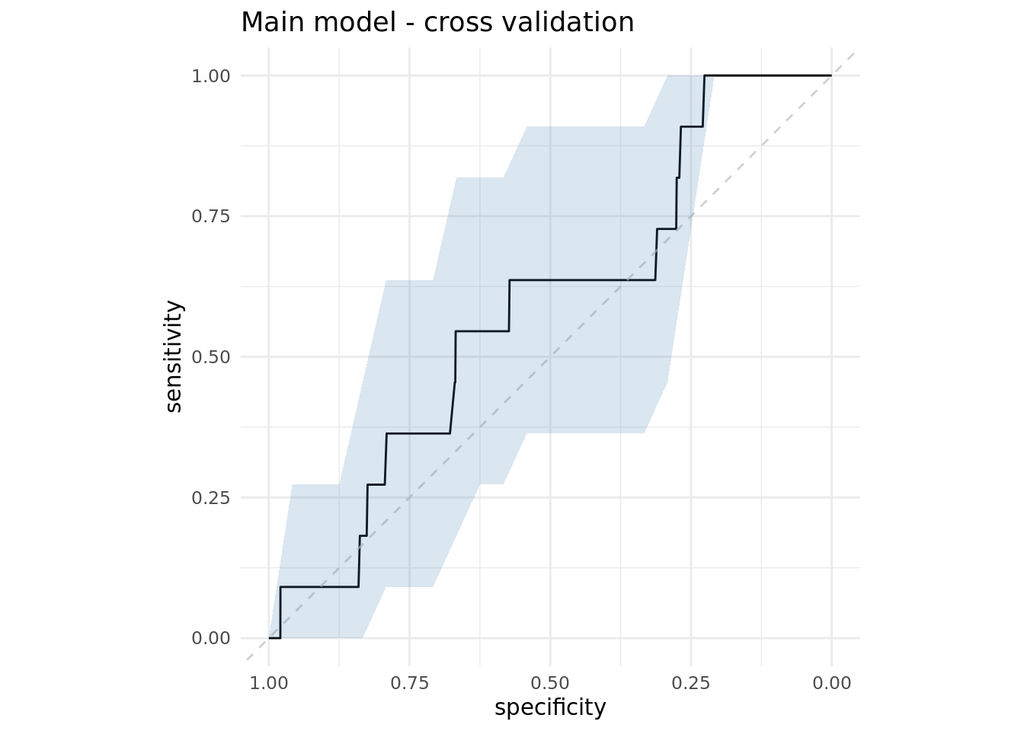

```r
# ROC curve with confidence interval
temporary$roc_plot
```

```r
# ROC-AUC
temporary$auc
```

```
## Area under the curve: 0.5851
```

```r
# ROC-AUC confidence interval
temporary$auc_ci
```

```
## 95% CI: 0.4248-0.7454 (DeLong)
```

# 2b) Upsampling outside cross-validation

In this variant descendants of the same case are present in different folds, however, the nesting of time-points within players is respected by performing cross-validation on the level of players. In other words: Compared to variation 2a the other potential information leakage is “open”.

## Fit gradient-boosted model with data upsampled outside cross-validation.

```r
data_training<-ROSE(Crit ~ ., data = data$data_training_wids, N = 50000, seed = 42)$data
player_in_training<-length(unique(data_training$ID))
CV_folds<-groupKFold(data_training$ID, k = player_in_training)
data_training<-select(data_training,!ID)

trainctrl_out <- trainControl(method = "repeatedcv", number = player_in_training, repeats = 10, summaryFunction = twoClassSummary, classProbs = TRUE, savePredictions = TRUE,index=CV_folds)  # no upsampling specified since it is already included in the training data

set.seed(42)
gbm_tree_auto_out <- train(Crit ~ ., data = data_training, method = "gbm", metric = "ROC", trControl = trainctrl_out, verbose = FALSE, tuneGrid = gbmGrid)
# Show model
gbm_tree_auto_out
```

```
## Stochastic Gradient Boosting
##
## 50000 samples
##    13 predictor
##     2 classes: 'No', 'Yes'
##
## No pre-processing
## Resampling: Cross-Validated (65 fold, repeated 10 times)
## Summary of sample sizes: 48864, 49434, 47114, 48791, 48001, 48925, ...
## Resampling results across tuning parameters:
##
##   interaction.depth  n.trees  ROC        Sens       Spec
##    1                  25      0.6148972  0.6282137  0.4211391
##    1                  50      0.6518079  0.6602754  0.5102412
##    1                  75      0.6584890  0.6619842  0.5283514
```

[output cut: 79 more lines]

```r
#End Parallel Computation
stopCluster(cl)
registerDoSEQ()
```

## Get cross-validation performance metrics

### ROC curve

```r
# Work with multiple threads (use all of the available ones)
gc()
```

```
##             used   (Mb) gc trigger   (Mb)  max used   (Mb)
## Ncells   2725125  145.6   28800845 1538.2  54048759 2886.6
## Vcells 131229475 1001.3  395582324 3018.1 965582101 7366.9
```

```r
cl <- makePSOCKcluster(14)
registerDoParallel(cl)

# Extract from fit object
predicted <- as.data.frame(gbm_tree_auto_out$pred$pred)
observed <- as.data.frame(gbm_tree_auto_out$pred$obs)
prob_no <- as.data.frame(gbm_tree_auto_out$pred$No)
prob_yes <- as.data.frame(gbm_tree_auto_out$pred$Yes)

# ROC curve and AUC
cv_roc_out <- cbind(predicted, observed, prob_no, prob_yes)
names(cv_roc_out) <- c("pred", "obs", "prob_no", "prob_yes")


cv_roc_out$obs_i <- cv_roc_out$obs == "Yes"

temporary<-generate_rocs(cv_roc_out)
```

```
## Progress disabled when using parallel plyr
```

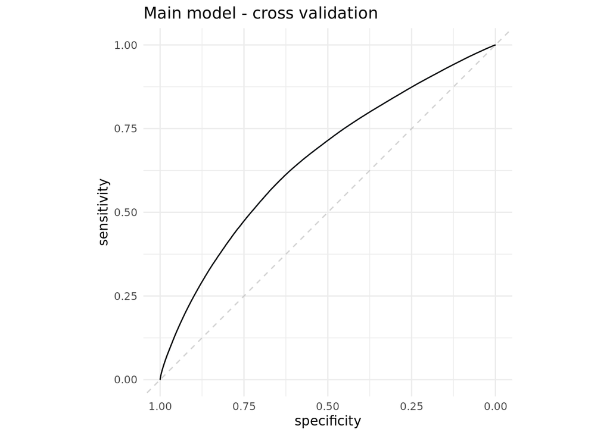

```r
# ROC curve with confidence interval
temporary$roc_plot
```

```r
# ROC-AUC
temporary$auc
```

```
## Area under the curve: 0.6553
```

```r
# ROC-AUC confidence interval
temporary$auc_ci
```

```
## 95% CI: 0.6548-0.6559 (DeLong)
```

### Discrimination - violin plots

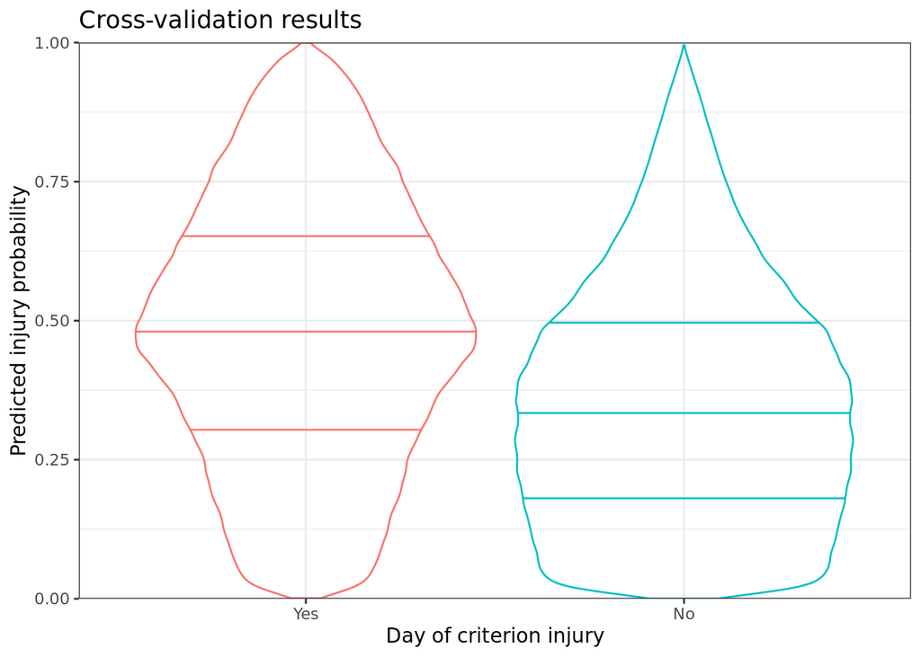

```r
violin_plot(cv_roc_out)
```

## Get testset predictions

```r
# Apply to test set
Predicted_out <- predict(gbm_tree_auto_out, newdata=data_test)

# View predictions for the test set
Predicted_out <- data.frame(Predicted_out)

# Merge with testset
data_test_plus_out <- cbind(data_test, Predicted_out)
data_test_plus_out$Predicted_out <- factor(data_test_plus_out$Predicted_out, levels = c("No", "Yes"))

# Check confusion matrix
table(data_test_plus_out$Crit, data_test_plus_out$Predicted_out)
```

```
##
##         No  Yes
##   No  3263 1280
##   Yes    5    6
```

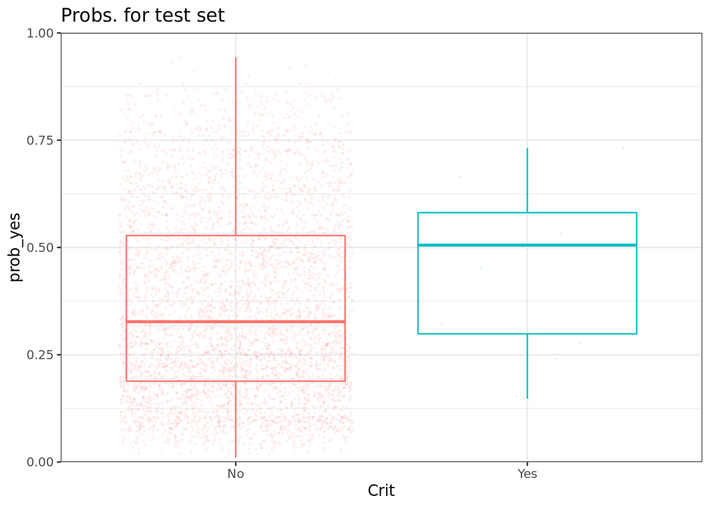

```r
## Get probabilities
Predicted_outp <- predict(gbm_tree_auto_out, newdata=data_test, type = "prob")
colnames(Predicted_outp) <- c("prob_no", "prob_yes")

# Merge
data_test_plus_out <- cbind(data_test_plus_out, Predicted_outp)

# Plot
ggplot(data_test_plus_out, aes(x=Crit, y=prob_yes, color = Crit))+ geom_jitter(alpha=0.1,size=0.6,shape=16)+ geom_boxplot(outlier.shape = NA,fill=NA)   + ggtitle("Probs. for test set")+guides(color="none")+ggplot_theme+scale_y_continuous(expand=c(0,0),limits = c(0,1))
```

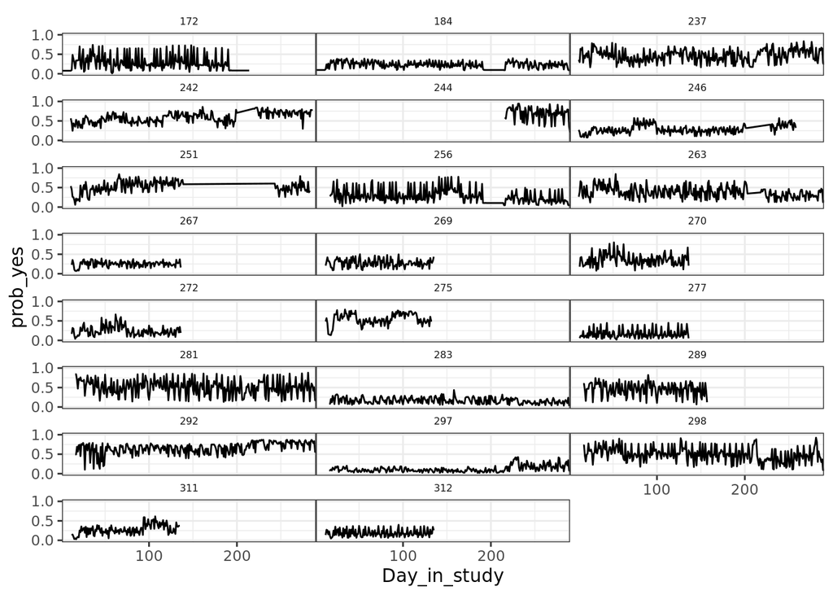

```r
ggplot(data_test_plus_out, aes(x=Day_in_study, y=prob_yes) ) + geom_line() +facet_wrap(~ID,ncol = 3) +scale_y_continuous(limits = c(0,1),breaks = c(0,0.5,1))+ggplot_theme+theme(strip.background = element_blank(),strip.text = element_text(size=6),panel.spacing = unit(0, "lines"))+scale_x_continuous(expand=c(0,0))
```

## Testset performance

#### ROC curve

```r
temporary<-generate_rocs(data_test_plus_out)
```

```
## Progress disabled when using parallel plyr
```

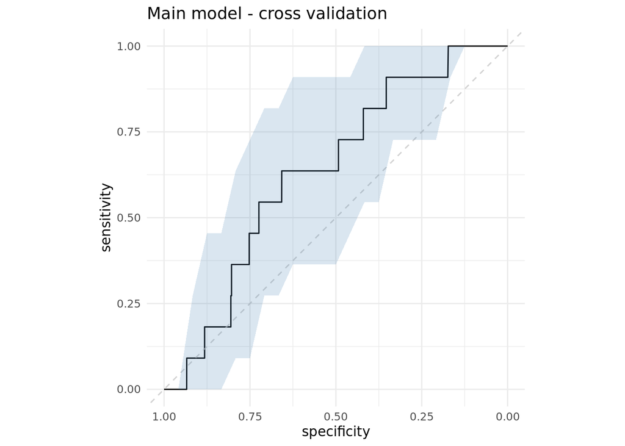

```r
# ROC curve with confidence interval
temporary$roc_plot
```

```r
# ROC-AUC
temporary$auc
```

```
## Area under the curve: 0.6362
```

```r
# ROC-AUC confidence interval
temporary$auc_ci
```

```
## 95% CI: 0.4925-0.7799 (DeLong)
```

# 2c) Upsampling outside cross-validation AND hierarchy not considered

In this variation of the analysis both potential sources of information leakage are combined (leading to marked inflation of cv-performance metrics)

## Fit gradient-boosted model

```r
trainctrl_leaky <- trainControl(method = "repeatedcv", number = player_in_training, repeats = 10, summaryFunction = twoClassSummary, classProbs = TRUE, savePredictions = TRUE)  # no index argument (CV_folds not used)!

set.seed(42)
gbm_tree_auto_leaky <- train(Crit ~ ., data = data_training, method = "gbm", metric = "ROC", trControl = trainctrl_leaky, verbose = FALSE, tuneGrid = gbmGrid)

# Show model
gbm_tree_auto_leaky
```

```
## Stochastic Gradient Boosting
##
## 50000 samples
##    13 predictor
##     2 classes: 'No', 'Yes'
##
## No pre-processing
## Resampling: Cross-Validated (65 fold, repeated 10 times)
## Summary of sample sizes: 49230, 49230, 49230, 49231, 49231, 49231, ...
## Resampling results across tuning parameters:
##
##   interaction.depth  n.trees  ROC        Sens       Spec
##    1                  25      0.7311204  0.6893699  0.6620338
##    1                  50      0.7520883  0.7202559  0.6626151
##    1                  75      0.7622872  0.7235502  0.6696126
```

[output cut: 79 more lines]

```r
#End Parallel Computation
stopCluster(cl)
registerDoSEQ()
```

## Get cross-validation performance metrics

### ROC curve

```r
# Work with multiple threads (use all of the available ones)
gc()
```

```
##             used   (Mb) gc trigger   (Mb)  max used   (Mb)
## Ncells   2732223  146.0    7549970  403.3  54048759 2886.6
## Vcells 470356275 3588.6 1058250786 8073.9 965818773 7368.7
```

```r
cl <- makePSOCKcluster(14)
registerDoParallel(cl)

# Extract from fit object
predicted <- as.data.frame(gbm_tree_auto_leaky$pred$pred)
observed <- as.data.frame(gbm_tree_auto_leaky$pred$obs)
prob_no <- as.data.frame(gbm_tree_auto_leaky$pred$No)
prob_yes <- as.data.frame(gbm_tree_auto_leaky$pred$Yes)

# ROC curve and AUC
cv_roc_leaky <- cbind(predicted, observed, prob_no, prob_yes)
names(cv_roc_leaky) <- c("pred", "obs", "prob_no", "prob_yes")


cv_roc_leaky$obs_i <- cv_roc_leaky$obs == "Yes"

temporary<-generate_rocs(cv_roc_leaky)
```

```
## Progress disabled when using parallel plyr
```

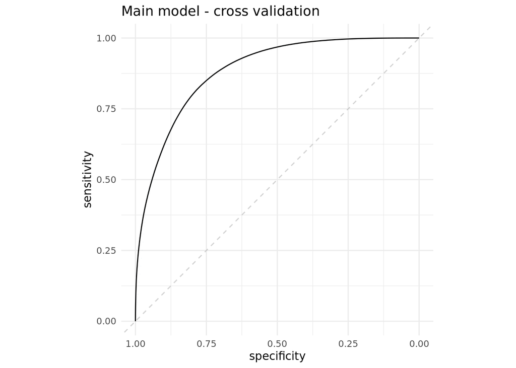

```r
# ROC curve with confidence interval
temporary$roc_plot
```

```r
# ROC-AUC
temporary$auc
```

```
## Area under the curve: 0.8842
```

```r
# ROC-AUC confidence interval
temporary$auc_ci
```

```
## 95% CI: 0.8841-0.8843 (DeLong)
```

### Discrimination - violin plots

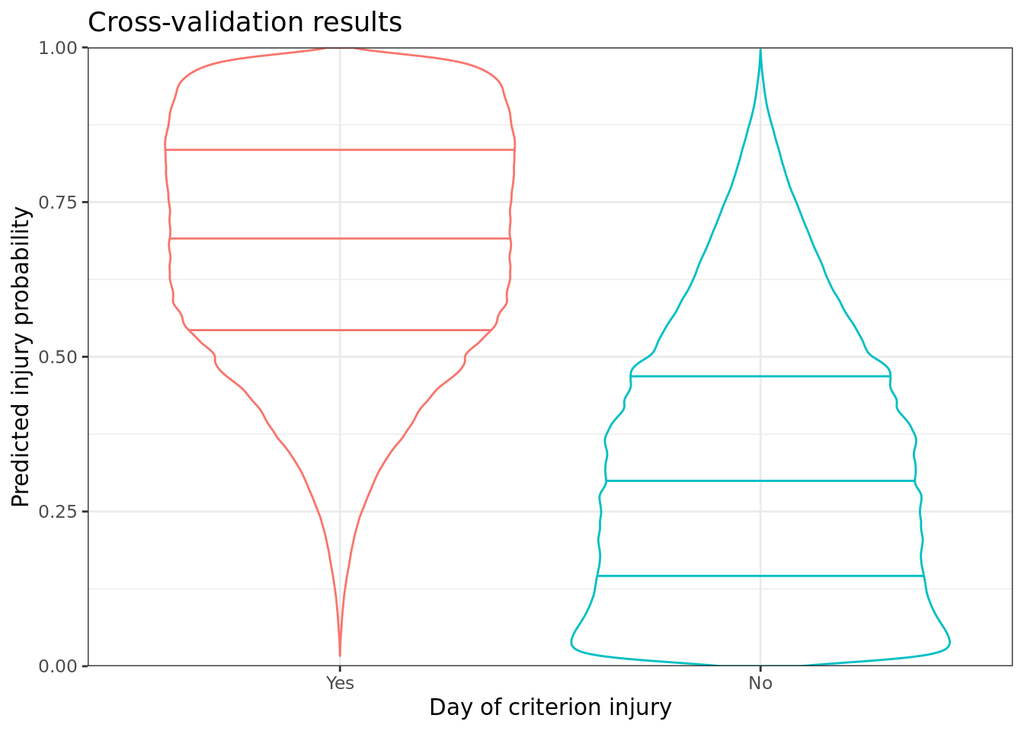

```r
violin_plot(cv_roc_leaky)
```

## Get testset predictions

```r
# Apply to test set
Predicted_leaky <- predict(gbm_tree_auto_leaky, newdata=data_test)

# View predictions for the test set
Predicted_leaky <- data.frame(Predicted_leaky)

# Merge with testset
data_test_plus_leaky <- cbind(data_test, Predicted_leaky)
data_test_plus_leaky$Predicted_leaky <- factor(data_test_plus_leaky$Predicted_leaky, levels = c("No", "Yes"))

# Check confusion matrix
table(data_test_plus_leaky$Crit, data_test_plus_leaky$Predicted_leaky)
```

```
##
##         No  Yes
##   No  3490 1053
##   Yes    6    5
```

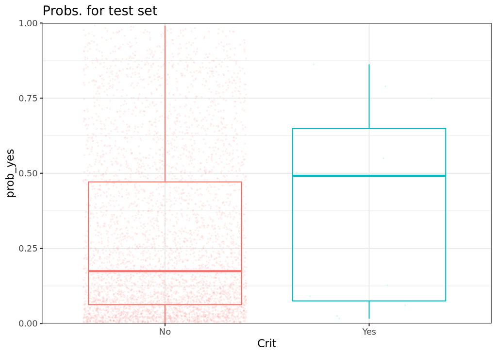

```r
## Get probabilities
Predicted_leakyp <- predict(gbm_tree_auto_leaky, newdata=data_test, type = "prob")
colnames(Predicted_leakyp) <- c("prob_no", "prob_yes")

# Merge
data_test_plus_leaky <- cbind(data_test_plus_leaky, Predicted_leakyp)

# Plot
ggplot(data_test_plus_leaky, aes(x=Crit, y=prob_yes, color = Crit))+ geom_jitter(alpha=0.1,size=0.6,shape=16)+ geom_boxplot(outlier.shape = NA,fill=NA)   + ggtitle("Probs. for test set")+guides(color="none")+ggplot_theme+scale_y_continuous(expand=c(0,0),limits = c(0,1))
```

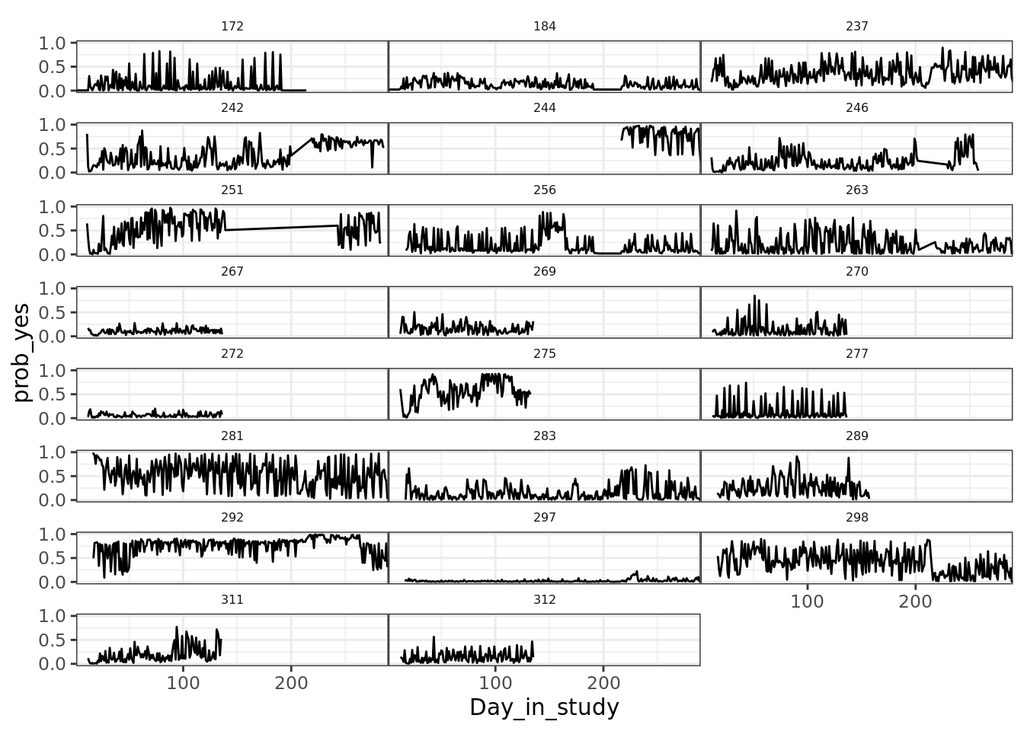

```r
ggplot(data_test_plus_leaky, aes(x=Day_in_study, y=prob_yes) ) + geom_line() +facet_wrap(~ID,ncol = 3) +scale_y_continuous(limits = c(0,1),breaks = c(0,0.5,1))+ggplot_theme+theme(strip.background = element_blank(),strip.text = element_text(size=6),panel.spacing = unit(0, "lines"))+scale_x_continuous(expand=c(0,0))
```

## Testset performance

### ROC curve

```r
temporary<-generate_rocs(data_test_plus_leaky)
```

```
## Progress disabled when using parallel plyr
```

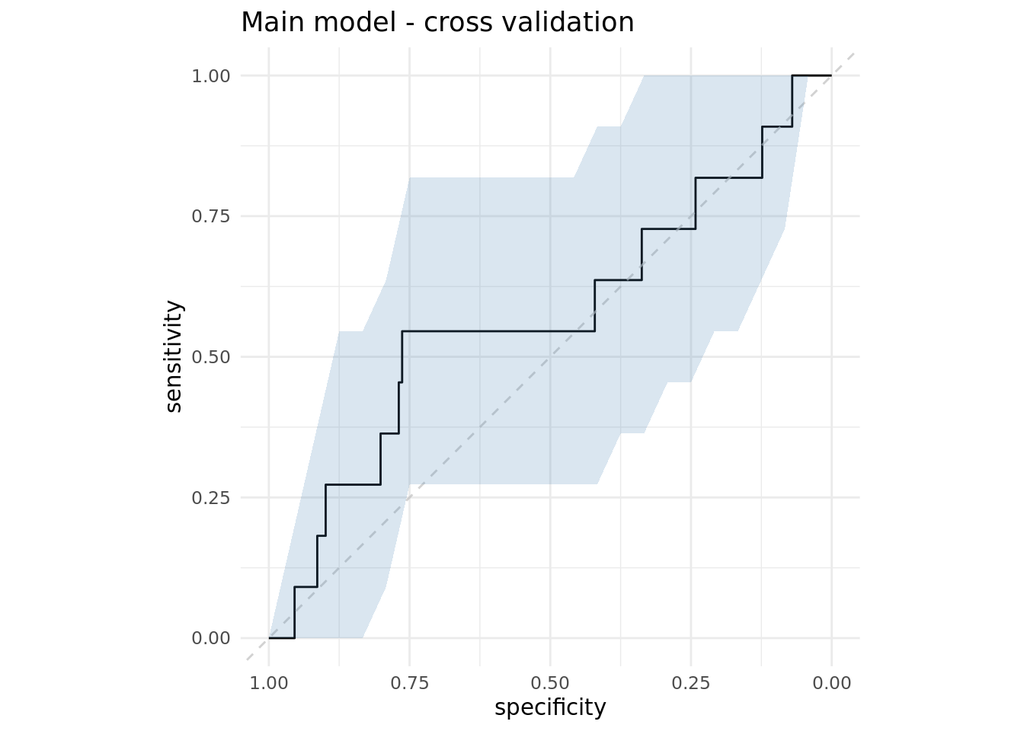

```r
# ROC curve with confidence interval
temporary$roc_plot
```

```r
# ROC-AUC
temporary$auc
```

```
## Area under the curve: 0.5722
```

```r
# ROC-AUC confidence interval
temporary$auc_ci
```

```
## 95% CI: 0.3728-0.7717 (DeLong)
```